# Experiment 2

## (1) Description of Data File

The posted data for this study consists of 1 compiled, deidentified data file (total *N* recruited = 130):

- 6 participants non-IAT lab data were not recorded due to technical difficulties
- Notes on cleaning IAT data (done in Excel according to [Lane et al., 2007](http://faculty.washington.edu/agg/IATmaterials/Summary%20of%20Improved%20Scoring%20Algorithm.pdf)):
  - 5 participants IAT data were either not recorded due to technical difficulties or were excluded for having more than 10% of responses <300ms
  - Trials >10,000ms: 0

## (2) Descriptive Statistics (Table 1)

**M<sub>age</sub> (*SD*):** 19.2 (1.14)

**Percentage by gender:**

```
## gender
##   <NA>   male female
##    0.0   31.5   68.5
```

**Percentage by race:**

```
## race
##          White          Asian          Black   Multi-racial         Latino Middle-Eastern
##           53.1           27.7            6.2            5.4            4.6            3.1
##           <NA>
##            0.0
```

**Percentage by class:**

```
## class
##  Freshman Sophomore    Junior    Senior      <NA>
##      62.3      22.3      10.8       4.6       0.0
```

**Percentage by income:**

```
## income.label
##   (1) $25,000 or less   (2) $25,001-$40,000   (3) $40,001-$70,000   (4) $70,001-$90,000
##                   6.2                   8.5                  12.3                  10.8
##  (5) $90,001-$120,000 (6) $120,001-$150,000 (7) $150,001-$200,000 (8) $200,001-$300,000
##                   8.5                   6.2                  10.8                  18.5
##  (9) $300,001 or more                  <NA>
##                  17.7                   0.8
```

*M*s and *SD*s for income and current GPA (cgpa):

*Note:* The *M* and *SD* for current GPA are slightly misreported in the published paper due to typoes. Correcting those values (as done here) does not change any conclusions or central values discussed in the paper.

```
##          n mean   sd
## income 129 5.69 2.64
## cgpa   123 3.39 0.39
```

## (3) Random Assignment Checks

**(a) Unequal variance test, *t*-test, and *M*s and *SD*s for: income**

```
##
##  F test to compare two variances
##
## data:  income by cond
## F = 1.1829, num df = 63, denom df = 59, p-value = 0.5163
## alternative hypothesis: true ratio of variances is not equal to 1
## 95 percent confidence interval:
##  0.7109946 1.9595288
## sample estimates:
## ratio of variances
##           1.182861
```

```
##
##  Two Sample t-test
##
## data:  income by cond
## t = 0.91341, df = 122, p-value = 0.3628
## alternative hypothesis: true difference in means is not equal to 0
## 95 percent confidence interval:
##  -0.5106775  1.3856775
## sample estimates:
##   mean in group warm mean in group chilly
##               5.9375               5.5000
```

```
##
##  Descriptive statistics by group
## group: warm
##    vars  n mean   sd median trimmed  mad min max range  skew kurtosis   se
## X1    1 64 5.94 2.77      7     6.1 2.97   1   9     8 -0.36    -1.47 0.35
## ---------------------------------------------------------------------------
## group: chilly
##    vars  n mean   sd median trimmed  mad min max range skew kurtosis   se
## X1    1 60  5.5 2.55    5.5     5.6 3.71   1   9     8 -0.2    -1.24 0.33
```

**(b) Unequal variance test, *t*-test, and *M*s and *SD*s for: current GPA**

```
##
##  F test to compare two variances
##
## data:  cgpa by cond
## F = 1.1489, num df = 62, denom df = 59, p-value = 0.5929
## alternative hypothesis: true ratio of variances is not equal to 1
## 95 percent confidence interval:
##  0.6895169 1.9079855
## sample estimates:
## ratio of variances
##           1.148854
```

```
##
##  Two Sample t-test
##
## data:  cgpa by cond
## t = 0.6379, df = 121, p-value = 0.5247
## alternative hypothesis: true difference in means is not equal to 0
## 95 percent confidence interval:
##  -0.09436224  0.18407970
## sample estimates:
##   mean in group warm mean in group chilly
##             3.416159             3.371300
```

```
##
##  Descriptive statistics by group
## group: warm
##    vars  n mean  sd median trimmed  mad min max range  skew kurtosis   se
## X1    1 63 3.42 0.4   3.49    3.44 0.43 2.4   4   1.6 -0.57    -0.69 0.05
## ---------------------------------------------------------------------------
## group: chilly
##    vars  n mean   sd median trimmed  mad min  max range  skew kurtosis   se
## X1    1 60 3.37 0.38   3.45    3.39 0.39 2.1 3.92  1.82 -0.75     0.83 0.05
```

## (4) Main Analyses

### Regressing IAT scores on condition, income, and their interaction (Table 2)

#### Omnibus test

**Estimates:**

```
##
## Call:
## lm(formula = iat ~ income_c * cond.num)
##
## Residuals:
##      Min       1Q   Median       3Q      Max
## -0.65603 -0.12138  0.04604  0.16810  0.73883
##
## Coefficients:
##                    Estimate Std. Error t value Pr(>|t|)
## (Intercept)        0.484124   0.026023  18.604   <2e-16 ***
## income_c           0.020531   0.009864   2.082   0.0396 *
## cond.num           0.033539   0.026023   1.289   0.2000
## income_c:cond.num -0.019817   0.009864  -2.009   0.0469 *
## ---
## Signif. codes:  0 '***' 0.001 '**' 0.01 '*' 0.05 '.' 0.1 ' ' 1
##
## Residual standard error: 0.283 on 115 degrees of freedom
##   (11 observations deleted due to missingness)
## Multiple R-squared:  0.07434,    Adjusted R-squared:  0.05019
## F-statistic: 3.078 on 3 and 115 DF,  p-value: 0.03035
```

**CIs:**

```
##                   2.5 % 97.5 %
## (Intercept)        0.43   0.54
## income_c           0.00   0.04
## cond.num          -0.02   0.09
## income_c:cond.num -0.04   0.00
```

*f*<sup>2</sup> value (effect size) for interaction term: 0.035

#### Simple slopes tests

**Simple slopes of condition among low- and high-SES students:**

```
##        [,1]
## warm      1
## chilly   -1
```

```
##
## ** Estimated points of iat  **
##
##                       Low cond.num (-1 SD) High cond.num (+1 SD)
## Low income_c (-1 SD)                0.3504                0.5210
## High income_c (+1 SD)               0.5597                0.5183
##
##
##
## ** Simple Slopes analysis ( df= 115 ) **
##
##                       simple slope standard error t-value p.value
## Low income_c (-1 SD)        0.0851         0.0368    2.31   0.023 *
## High income_c (+1 SD)      -0.0206         0.0372   -0.56   0.580
## ---
## Signif. codes:  0 '***' 0.001 '**' 0.01 '*' 0.05 '.' 0.1 ' ' 1
##
##
##
## ** Bauer & Curran 95% CI **
##
##          lower CI upper CI
## income_c  -1.1178   69.655
```

**CIs for simple slope among low-SES students:** 0.01, 0.16

**CIs for simple slope among high-SES students:** -0.09, 0.05  
**Simple slope of income in each condition (Footnote 3):**

```
##        [,1]
## warm      1
## chilly   -1
```

```
##
## ** Estimated points of iat  **
##
##                       Low income_c (-1 SD) High income_c (+1 SD)
## Low cond.num (-1 SD)                0.3504                0.5597
## High cond.num (+1 SD)               0.5210                0.5183
##
##
##
## ** Simple Slopes analysis ( df= 115 ) **
##
##                       simple slope standard error t-value p.value
## Low cond.num (-1 SD)        0.0392         0.0144    2.72  0.0076 **
## High cond.num (+1 SD)      -0.0005         0.0134   -0.04  0.9702
## ---
## Signif. codes:  0 '***' 0.001 '**' 0.01 '*' 0.05 '.' 0.1 ' ' 1
##
##
##
## ** Bauer & Curran 95% CI **
##
##          lower CI upper CI
## cond.num    0.067   37.624
```

**CIs for simple slope among students in the chilly climate condition:** 0.01, 0.07

**CIs for simple slope among students in the warm climate condition:** -0.03, 0.03

### Analysis with subjective SES (Footnote 2)

```
##
## Call:
## lm(formula = iat ~ ladder_c * cond.num)
##
## Residuals:
##      Min       1Q   Median       3Q      Max
## -0.71833 -0.15120  0.03657  0.16714  0.83017
##
## Coefficients:
##                    Estimate Std. Error t value Pr(>|t|)
## (Intercept)        0.483271   0.026660  18.127   <2e-16 ***
## ladder_c           0.023252   0.014864   1.564    0.120
## cond.num           0.030771   0.026660   1.154    0.251
## ladder_c:cond.num -0.006834   0.014864  -0.460    0.647
## ---
## Signif. codes:  0 '***' 0.001 '**' 0.01 '*' 0.05 '.' 0.1 ' ' 1
##
## Residual standard error: 0.2884 on 115 degrees of freedom
##   (11 observations deleted due to missingness)
## Multiple R-squared:  0.03834,    Adjusted R-squared:  0.01325
## F-statistic: 1.528 on 3 and 115 DF,  p-value: 0.211
```

## (5) Figures

### Regressing IAT scores on condition, income, and their interaction (Figure 2)

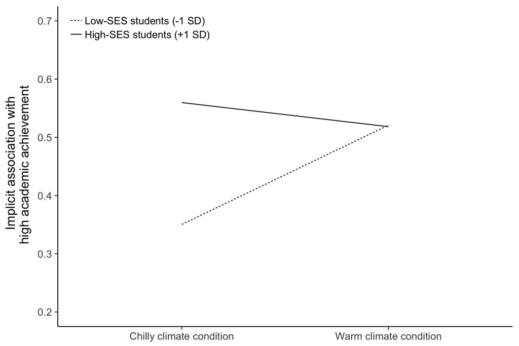